# Prosper Loan Data - Visualizations

## Preliminary Wrangling

Prosper Marketplace is America's first peer-to-peer lending marketplace, with over 7 billion USD in funded loans. Borrowers request personal loans on Prosper and investors (individual or institutional) can fund anywhere from 2,000 USD to 35,000 USD per loan request. Investors can consider borrowers’ credit scores, ratings, and histories and the category of the loan. Prosper handles the servicing of the loan and collects and distributes borrower payments and interest back to the loan investors. [ref. https://en.wikipedia.org/wiki/Prosper_Marketplace]

The data set contains 113,937 loans with 81 variables on each loan, including loan amount, borrower rate (or interest rate), current loan status, borrower income, and many others.

Details with regards to variables can be found here: https://docs.google.com/spreadsheet/ccc?key=0AllIqIyvWZdadDd5NTlqZ1pBMHlsUjdrOTZHaVBuSlE&usp=sharing and here: https://www.prosper.com/Downloads/Services/Documentation/ProsperAPI_Objects_Details.html

```python
# import all packages and set plots to be embedded inline
import numpy as np
import pandas as pd
import matplotlib.pyplot as plt
import seaborn as sb

%matplotlib inline
```

Load in the dataset

```python
loan_df=pd.read_csv('prosperLoanData.csv')
loan_df.head()
```

|  | ListingKey | ListingNumber | ListingCreationDate | CreditGrade | Term | LoanStatus | ClosedDate | BorrowerAPR | BorrowerRate | LenderYield | ... | LP_ServiceFees | LP_CollectionFees | LP_GrossPrincipalLoss | LP_NetPrincipalLoss | LP_NonPrincipalRecoverypayments | PercentFunded | Recommendations | InvestmentFromFriendsCount | InvestmentFromFriendsAmount | Investors |
| --- | --- | --- | --- | --- | --- | --- | --- | --- | --- | --- | --- | --- | --- | --- | --- | --- | --- | --- | --- | --- | --- |
| 0 | 1021339766868145413AB3B | 193129 | 2007-08-26 19:09:29.263000000 | C | 36 | Completed | 2009-08-14 00:00:00 | 0.16516 | 0.1580 | 0.1380 | ... | -133.18 | 0.0 | 0.0 | 0.0 | 0.0 | 1.0 | 0 | 0 | 0.0 | 258 |
| 1 | 10273602499503308B223C1 | 1209647 | 2014-02-27 08:28:07.900000000 | NaN | 36 | Current | NaN | 0.12016 | 0.0920 | 0.0820 | ... | 0.00 | 0.0 | 0.0 | 0.0 | 0.0 | 1.0 | 0 | 0 | 0.0 | 1 |
| 2 | 0EE9337825851032864889A | 81716 | 2007-01-05 15:00:47.090000000 | HR | 36 | Completed | 2009-12-17 00:00:00 | 0.28269 | 0.2750 | 0.2400 | ... | -24.20 | 0.0 | 0.0 | 0.0 | 0.0 | 1.0 | 0 | 0 | 0.0 | 41 |
| 3 | 0EF5356002482715299901A | 658116 | 2012-10-22 11:02:35.010000000 | NaN | 36 | Current | NaN | 0.12528 | 0.0974 | 0.0874 | ... | -108.01 | 0.0 | 0.0 | 0.0 | 0.0 | 1.0 | 0 | 0 | 0.0 | 158 |
| 4 | 0F023589499656230C5E3E2 | 909464 | 2013-09-14 18:38:39.097000000 | NaN | 36 | Current | NaN | 0.24614 | 0.2085 | 0.1985 | ... | -60.27 | 0.0 | 0.0 | 0.0 | 0.0 | 1.0 | 0 | 0 | 0.0 | 20 |

5 rows × 81 columns

```python
loan_df.shape
```

```
(113937, 81)
```

```python
loan_df.info()
```

```
<class 'pandas.core.frame.DataFrame'>
RangeIndex: 113937 entries, 0 to 113936
Data columns (total 81 columns):
ListingKey                             113937 non-null object
ListingNumber                          113937 non-null int64
ListingCreationDate                    113937 non-null object
CreditGrade                            28953 non-null object
Term                                   113937 non-null int64
LoanStatus                             113937 non-null object
ClosedDate                             55089 non-null object
BorrowerAPR                            113912 non-null float64
BorrowerRate                           113937 non-null float64
LenderYield                            113937 non-null float64
EstimatedEffectiveYield                84853 non-null float64
EstimatedLoss                          84853 non-null float64
EstimatedReturn                        84853 non-null float64
ProsperRating (numeric)                84853 non-null float64
ProsperRating (Alpha)                  84853 non-null object
ProsperScore                           84853 non-null float64
ListingCategory (numeric)              113937 non-null int64
BorrowerState                          108422 non-null object
Occupation                             110349 non-null object
EmploymentStatus                       111682 non-null object
EmploymentStatusDuration               106312 non-null float64
IsBorrowerHomeowner                    113937 non-null bool
CurrentlyInGroup                       113937 non-null bool
GroupKey                               13341 non-null object
DateCreditPulled                       113937 non-null object
CreditScoreRangeLower                  113346 non-null float64
CreditScoreRangeUpper                  113346 non-null float64
FirstRecordedCreditLine                113240 non-null object
CurrentCreditLines                     106333 non-null float64
OpenCreditLines                        106333 non-null float64
TotalCreditLinespast7years             113240 non-null float64
OpenRevolvingAccounts                  113937 non-null int64
OpenRevolvingMonthlyPayment            113937 non-null float64
InquiriesLast6Months                   113240 non-null float64
TotalInquiries                         112778 non-null float64
CurrentDelinquencies                   113240 non-null float64
AmountDelinquent                       106315 non-null float64
```

[output cut: 31 more lines]

```
LP_CustomerPayments                    113937 non-null float64
LP_CustomerPrincipalPayments           113937 non-null float64
LP_InterestandFees                     113937 non-null float64
LP_ServiceFees                         113937 non-null float64
LP_CollectionFees                      113937 non-null float64
LP_GrossPrincipalLoss                  113937 non-null float64
LP_NetPrincipalLoss                    113937 non-null float64
LP_NonPrincipalRecoverypayments        113937 non-null float64
PercentFunded                          113937 non-null float64
Recommendations                        113937 non-null int64
InvestmentFromFriendsCount             113937 non-null int64
InvestmentFromFriendsAmount            113937 non-null float64
Investors                              113937 non-null int64
dtypes: bool(3), float64(50), int64(11), object(17)
memory usage: 68.1+ MB
```

We can check descriptive statistics for numeric variables, however. Since we have too many variables it doesn't give clear overview of the variables behaviour.

```python
# descriptive statistics for numeric variables
print(loan_df.describe())
```

```
       ListingNumber           Term    BorrowerAPR   BorrowerRate  \
count   1.139370e+05  113937.000000  113912.000000  113937.000000
mean    6.278857e+05      40.830248       0.218828       0.192764
std     3.280762e+05      10.436212       0.080364       0.074818
min     4.000000e+00      12.000000       0.006530       0.000000
25%     4.009190e+05      36.000000       0.156290       0.134000
50%     6.005540e+05      36.000000       0.209760       0.184000
75%     8.926340e+05      36.000000       0.283810       0.250000
max     1.255725e+06      60.000000       0.512290       0.497500

         LenderYield  EstimatedEffectiveYield  EstimatedLoss  EstimatedReturn  \
count  113937.000000             84853.000000   84853.000000     84853.000000
mean        0.182701                 0.168661       0.080306         0.096068
std         0.074516                 0.068467       0.046764         0.030403
min        -0.010000                -0.182700       0.004900        -0.182700
25%         0.124200                 0.115670       0.042400         0.074080
50%         0.173000                 0.161500       0.072400         0.091700
75%         0.240000                 0.224300       0.112000         0.116600
max         0.492500                 0.319900       0.366000         0.283700

       ProsperRating (numeric)  ProsperScore      ...        LP_ServiceFees  \
count             84853.000000  84853.000000      ...         113937.000000
mean                  4.072243      5.950067      ...            -54.725641
std                   1.673227      2.376501      ...             60.675425
min                   1.000000      1.000000      ...           -664.870000
25%                   3.000000      4.000000      ...            -73.180000
50%                   4.000000      6.000000      ...            -34.440000
75%                   5.000000      8.000000      ...            -13.920000
max                   7.000000     11.000000      ...             32.060000

       LP_CollectionFees  LP_GrossPrincipalLoss  LP_NetPrincipalLoss  \
count      113937.000000          113937.000000        113937.000000
mean          -14.242698             700.446342           681.420499
std           109.232758            2388.513831          2357.167068
min         -9274.750000             -94.200000          -954.550000
25%             0.000000               0.000000             0.000000
50%             0.000000               0.000000             0.000000
75%             0.000000               0.000000             0.000000
max             0.000000           25000.000000         25000.000000

       LP_NonPrincipalRecoverypayments  PercentFunded  Recommendations  \
count                    113937.000000  113937.000000    113937.000000
mean                         25.142686       0.998584         0.048027
std                         275.657937       0.017919         0.332353
min                           0.000000       0.700000         0.000000
25%                           0.000000       1.000000         0.000000
50%                           0.000000       1.000000         0.000000
75%                           0.000000       1.000000         0.000000
max                       21117.900000       1.012500        39.000000

       InvestmentFromFriendsCount  InvestmentFromFriendsAmount      Investors
count               113937.000000                113937.000000  113937.000000
mean                     0.023460                    16.550751      80.475228
std                      0.232412                   294.545422     103.239020
min                      0.000000                     0.000000       1.000000
25%                      0.000000                     0.000000       2.000000
50%                      0.000000                     0.000000      44.000000
75%                      0.000000                     0.000000     115.000000
max                     33.000000                 25000.000000    1189.000000

[8 rows x 61 columns]
```

Some records contains duplicated item, pay attention and probably delete these records for proper analysis.

```python
loan_df['LoanKey'].value_counts().head()
```

```
CB1B37030986463208432A1    6
2DEE3698211017519D7333F    4
9F4B37043517554537C364C    4
E6FB37073953690388BC56D    4
D895370150591392337ED6D    4
Name: LoanKey, dtype: int64
```

```python
loan_df[loan_df['LoanKey']=='2DEE3698211017519D7333F']
```

|  | ListingKey | ListingNumber | ListingCreationDate | CreditGrade | Term | LoanStatus | ClosedDate | BorrowerAPR | BorrowerRate | LenderYield | ... | LP_ServiceFees | LP_CollectionFees | LP_GrossPrincipalLoss | LP_NetPrincipalLoss | LP_NonPrincipalRecoverypayments | PercentFunded | Recommendations | InvestmentFromFriendsCount | InvestmentFromFriendsAmount | Investors |
| --- | --- | --- | --- | --- | --- | --- | --- | --- | --- | --- | --- | --- | --- | --- | --- | --- | --- | --- | --- | --- | --- |
| 27178 | 349D3587495831350F0F648 | 882888 | 2013-08-28 20:31:41.107000000 | NaN | 36 | Current | NaN | 0.13189 | 0.1039 | 0.0939 | ... | -34.44 | 0.0 | 0.0 | 0.0 | 0.0 | 1.0 | 0 | 0 | 0.0 | 1 |
| 29528 | 349D3587495831350F0F648 | 882888 | 2013-08-28 20:31:41.107000000 | NaN | 36 | Current | NaN | 0.13189 | 0.1039 | 0.0939 | ... | -34.44 | 0.0 | 0.0 | 0.0 | 0.0 | 1.0 | 0 | 0 | 0.0 | 1 |
| 37941 | 349D3587495831350F0F648 | 882888 | 2013-08-28 20:31:41.107000000 | NaN | 36 | Current | NaN | 0.13189 | 0.1039 | 0.0939 | ... | -34.44 | 0.0 | 0.0 | 0.0 | 0.0 | 1.0 | 0 | 0 | 0.0 | 1 |
| 71930 | 349D3587495831350F0F648 | 882888 | 2013-08-28 20:31:41.107000000 | NaN | 36 | Current | NaN | 0.13189 | 0.1039 | 0.0939 | ... | -34.44 | 0.0 | 0.0 | 0.0 | 0.0 | 1.0 | 0 | 0 | 0.0 | 1 |

4 rows × 81 columns

### What is the structure of your dataset?

The dataset contains information about 113,937 loans with 81 features. The data looks relatively tidy with some missing values, but we will not spend too much time on cleaning it now.

### What is/are the main feature(s) of interest in your dataset?

It's pinteresting to understand what parameters influence Prosper rating of individuals (inquiries) and rate at which loan is issued. Furthermore, performance behaviour of the loans is very important, is it positively performing loan or not, was the rating system correct when assigned positive rating to an individual?

### What features in the dataset do you think will help support your investigation into your feature(s) of interest?

I will explore behaviour of the following variables in this project:

- Term: The length of the loan expressed in months.
- LoanStatus: The current status of the loan: Cancelled, Chargedoff, Completed, Current, Defaulted, FinalPaymentInProgress, PastDue. The PastDue status will be accompanied by a delinquency bucket.
- BorrowerAPR: The Borrower's Annual Percentage Rate (APR) for the loan.
- BorrowerRate: The Borrower's interest rate for this loan.
- CreditGrade: The Credit rating that was assigned at the time the listing went live. Applicable for listings pre-2009 period and will only be populated for those listings.
- ProsperRating (Alpha): The Prosper Rating assigned at the time the listing was created between AA - HR. Applicable for loans originated after July 2009.
- ListingCategory: The category of the listing that the borrower selected when posting their listing: 0 - Not Available, 1 - Debt Consolidation, 2 - Home Improvement, 3 - Business, 4 - Personal Loan, 5 - Student Use, 6 - Auto, 7- Other, 8 - Baby&Adoption, 9 - Boat, 10 - Cosmetic Procedure, 11 - Engagement Ring, 12 - Green Loans, 13 - Household Expenses, 14 - Large Purchases, 15 - Medical/Dental, 16 - Motorcycle, 17 - RV, 18 - Taxes, 19 - Vacation, 20 - Wedding Loans
- EmploymentStatus: The employment status of the borrower at the time they posted the listing.
- IsBorrowerHomeowner: A Borrower will be classified as a homowner if they have a mortgage on their credit profile or provide documentation confirming they are a homeowner.
- CreditScoreRangeLower: The lower value representing the range of the borrower's credit score as provided by a consumer credit rating agency.
- CreditScoreRangeUpper: The upper value representing the range of the borrower's credit score as provided by a consumer credit rating agency.
- InquiriesLast6Months: Number of inquiries in the past six months at the time the credit profile was pulled.
- DebtToIncomeRatio: The debt to income ratio of the borrower at the time the credit profile was pulled. This value is Null if the debt to income ratio is not available. This value is capped at 10.01 (any debt to income ratio larger than 1000% will be returned as 1001%).
- IncomeRange: The income range of the borrower at the time the listing was created.
- StatedMonthlyIncome: The monthly income the borrower stated at the time the listing was created.
- TotalProsperLoans: Number of Prosper loans the borrower at the time they created this listing. This value will be null if the borrower had no prior loans.
- LoanNumber Unique numeric value associated with the loan.
- LoanOriginalAmount: The origination amount of the loan.
- LoanOriginationDate: The date the loan was originated.
- LoanOriginationQuarter: The quarter in which the loan was originated.
- MonthlyLoanPayment: The scheduled monthly loan payment.
- PercentFunded: Percent the listing was funded.
- Recommendations: Number of recommendations the borrower had at the time the listing was created.
- InvestmentFromFriendsCount: Number of friends that made an investment in the loan.
- InvestmentFromFriendsAmount: Dollar amount of investments that were made by friends.

## 1. Univariate Exploration

```python
# define base color
base_color = sb.color_palette()[0]
# extract loan rigination year
loan_df['LoanOriginationDate_year']=pd.DatetimeIndex(loan_df['LoanOriginationDate']).year
```

### 1.1 Term (Duration of loan)

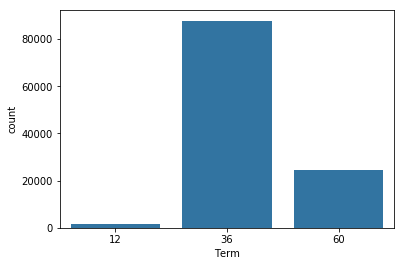

```python
sb.countplot(data = loan_df, x = 'Term', color=base_color);
```

Most loans are taken for 36 month (3 years), very few are taken for one year.

### 1.2 Loan status

```python
loan_df['LoanStatus'].value_counts()
```

```
Current                   56576
Completed                 38074
Chargedoff                11992
Defaulted                  5018
Past Due (1-15 days)        806
Past Due (31-60 days)       363
Past Due (61-90 days)       313
Past Due (91-120 days)      304
Past Due (16-30 days)       265
FinalPaymentInProgress      205
Past Due (>120 days)         16
Cancelled                     5
Name: LoanStatus, dtype: int64
```

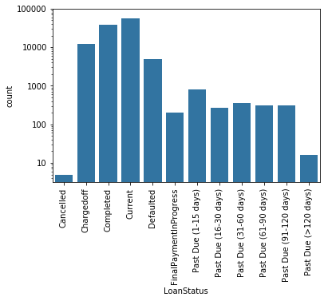

```python
loan_order=['Cancelled', 'Chargedoff', 'Completed', 'Current', 'Defaulted', 'FinalPaymentInProgress', 'Past Due (1-15 days)',
            'Past Due (16-30 days)', 'Past Due (31-60 days)', 'Past Due (61-90 days)', 'Past Due (91-120 days)','Past Due (>120 days)' ]

sb.countplot(data = loan_df, x = 'LoanStatus', color=base_color, order=loan_order)
plt.xticks(rotation = 90)
plt.yscale('log')
tick_locs = [10, 100, 1000, 10000, 100000]
plt.yticks(tick_locs, tick_locs);
```

Most of loans are 'Completed' or 'Current'. Logarithmic transformation of y-axis is required to observe relatively small values of 'Past Due (XX days)'. Let's regroup the dataframe by loan performance.

```python
loan_df['Performing']=np.nan
#loan_df[(loan_df['LoanStatus']=='Completed')|(loan_df['LoanStatus']=='Current')|(loan_df['LoanStatus']=='FinalPaymentInprogress')]
loan_df.loc[(loan_df['LoanStatus']=='Completed')|#(loan_df['LoanStatus']=='Current')|
            (loan_df['LoanStatus']=='FinalPaymentInProgress'), 'Performing']='Performing'
loan_df.loc[(loan_df['LoanStatus']=='Chargedoff')|(loan_df['LoanStatus']=='Defaulted')|
            (loan_df['LoanStatus']=='Past Due (1-15 days)') |(loan_df['LoanStatus']=='Past Due (16-30 days)')|
            (loan_df['LoanStatus']=='Past Due (31-60 days)')|(loan_df['LoanStatus']=='Past Due (61-90 days)')|
            (loan_df['LoanStatus']=='Past Due (91-120 days)')|(loan_df['LoanStatus']=='Past Due (>120 days)'),#|
            #(loan_df['LoanStatus']=='Cancelled'),
            'Performing']='Non-Performing'
loan_df.loc[(loan_df['LoanStatus']=='Current'), 'Performing']='Current'
```

```python
loan_df['Performing'].value_counts()
```

```
Current           56576
Performing        38279
Non-Performing    19077
Name: Performing, dtype: int64
```

```python
loan_df[loan_df['Performing']=='Non-Performing'].shape[0]/(loan_df[loan_df['Performing']=='Performing'].shape[0]+loan_df[loan_df['Performing']=='Non-Performing'].shape[0])
```

```
0.33260687635121
```

About 33 % of loans didn't perform. It's really high.

### 1.3 Borrower APR

```python
loan_df['BorrowerAPR'].dtypes
```

```
dtype('float64')
```

```python
loan_df['BorrowerAPR'].describe()
```

```
count    113912.000000
mean          0.218828
std           0.080364
min           0.006530
25%           0.156290
50%           0.209760
75%           0.283810
max           0.512290
Name: BorrowerAPR, dtype: float64
```

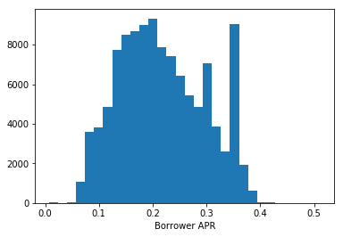

```python
plt.hist(data = loan_df, x = 'BorrowerAPR', bins=30)
plt.xlabel('Borrower APR');
```

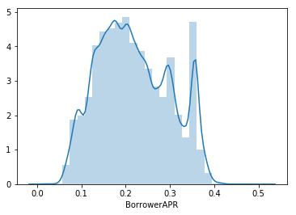

```python
sb.distplot(loan_df['BorrowerAPR'], bins = 30, hist_kws = {'alpha' : 0.3});
```

Borrower APR rate looks normally distributed with few spikes around 0.3 and 0.35. Rates are relatively high (~20%).

### 1.4 Borrower Rate

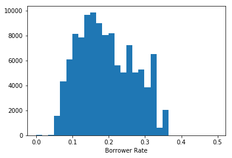

```python
plt.hist(data = loan_df, x = 'BorrowerRate', bins=30)
plt.xlabel('Borrower Rate');
```

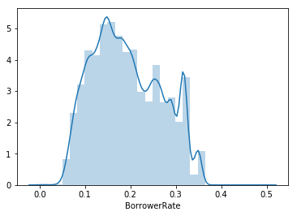

```python
sb.distplot(loan_df['BorrowerRate'], bins = 30, hist_kws = {'alpha' : 0.3});
```

Borrower's Rate follows similar pattern as the APR rate with slightly lower rates (avg of 18-19%). The APR (Annual Percentage Rate) reflects the annual cost of a loan to a borrower including any fees charged to originate the loan.

### 1.5 Prosper Rating

It seems that before 2009 'Credit Grade' parameter was used and 'ProsperRating (numeric)' after 2009. Am I right?

**Credit Grade**

```python
loan_df['CreditGrade'].value_counts()
```

```
C     5649
D     5153
B     4389
AA    3509
HR    3508
A     3315
E     3289
NC     141
Name: CreditGrade, dtype: int64
```

```python
loan_df[loan_df['CreditGrade'].isna()]['LoanOriginationDate_year'].value_counts()
```

```
2013    34345
2012    19553
2014    12172
2011    11228
2010     5652
2009     2034
Name: LoanOriginationDate_year, dtype: int64
```

```python
loan_df[~loan_df['CreditGrade'].isna()]['LoanOriginationDate_year'].value_counts()
```

```
2008    11552
2007    11460
2006     5906
2005       22
2009       13
Name: LoanOriginationDate_year, dtype: int64
```

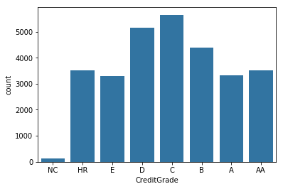

```python
CreditGrade_order=['NC', 'HR', 'E', 'D', 'C', 'B', 'A', 'AA']
sb.countplot(loan_df['CreditGrade'], color=base_color, order=CreditGrade_order);
```

Credit Grade distribution has peaks at 'D' and 'C'-graded users.

**Prosper Rating (Alpha)**

```python
loan_df[loan_df['ProsperRating (Alpha)'].isna()]['LoanOriginationDate_year'].value_counts()
```

```
2008    11552
2007    11460
2006     5906
2010       73
2009       71
2005       22
Name: LoanOriginationDate_year, dtype: int64
```

There is still 144 'NaN' values in 2009 and 2010.

```python
loan_df[~loan_df['ProsperRating (Alpha)'].isna()]['LoanOriginationDate_year'].value_counts()
```

```
2013    34345
2012    19553
2014    12172
2011    11228
2010     5579
2009     1976
Name: LoanOriginationDate_year, dtype: int64
```

```python
#loan_df.loc[loan_df['ProsperRating (Alpha)'].isna(), 'ProsperRating (Alpha)']=0
```

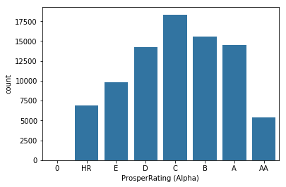

```python
ProsperRating_order=[0, 'HR', 'E', 'D', 'C', 'B', 'A', 'AA']
sb.countplot(loan_df['ProsperRating (Alpha)'], color=base_color, order=ProsperRating_order);
```

Prosper rating looks normally distributed, if we exclude 'NAN' values for records before 2009 or missing data.

Let's combine ratings before and after 2009 in one variable 'ProsperRating_combined'.

```python
loan_df[loan_df['ProsperRating (Alpha)']==0]['LoanOriginationDate_year'].value_counts()
```

```
Series([], Name: LoanOriginationDate_year, dtype: int64)
```

```python
loan_df['ProsperRating_combined']=np.nan
loan_df.loc[~loan_df['CreditGrade'].isna(), 'ProsperRating_combined']=loan_df[~loan_df['CreditGrade'].isna()]['CreditGrade']
loan_df.loc[~loan_df['ProsperRating (Alpha)'].isna(), 'ProsperRating_combined']=loan_df[~loan_df['ProsperRating (Alpha)'].isna()]['ProsperRating (Alpha)']
```

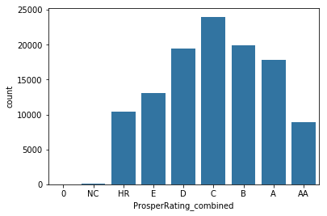

```python
ProsperRating_order=[0, 'NC','HR', 'E', 'D', 'C', 'B', 'A', 'AA']
sb.countplot(loan_df['ProsperRating_combined'], color=base_color, order=ProsperRating_order);
```

The ProsperRating_combined variable is normally distributed with mean at C-graded users.

I will add new column '2009' indicating if record comes from period of time before 2009 or after (before or after the crisis).

```python
loan_df['2009']=np.nan
loan_df.loc[~loan_df['CreditGrade'].isna(), '2009']='before 2009'
loan_df.loc[~loan_df['ProsperRating (Alpha)'].isna(), '2009']='after 2009'
```

```python
loan_df['2009'].value_counts()
```

```
after 2009     84853
before 2009    28953
Name: 2009, dtype: int64
```

### 1.6 Listing Category

The category of the listing that the borrower selected when posting their listing: 0 - Not Available, 1 - Debt Consolidation, 2 - Home Improvement, 3 - Business, 4 - Personal Loan, 5 - Student Use, 6 - Auto, 7- Other, 8 - Baby&Adoption, 9 - Boat, 10 - Cosmetic Procedure, 11 - Engagement Ring, 12 - Green Loans, 13 - Household Expenses, 14 - Large Purchases, 15 - Medical/Dental, 16 - Motorcycle, 17 - RV, 18 - Taxes, 19 - Vacation, 20 - Wedding Loans

```python
ListingCategory_dict = {0 : "Not Available", 1 : "Debt Consolidation", 2: "Home Improvement",
                        3 : "Business", 4 : "Personal Loan", 5 : "Student Use", 6 : "Auto",
                        7: "Other", 8 : "Baby&Adoption", 9 : "Boat", 10 : "Cosmetic Procedure",
                        11 : "Engagement Ring", 12 : "Green Loans", 13 : "Household Expenses",
                        14 : "Large Purchases", 15 : "Medical/Dental", 16 : "Motorcycle", 17 : "RV",
                        18 : "Taxes", 19 : "Vacation", 20 : "Wedding Loans"}
#ListingCategory_dict
```

```python
ListingCategory_order=loan_df['ListingCategory (numeric)'].value_counts().index
loan_df['ListingCategory (numeric)'].value_counts()
ListingCategory_order
```

```
Int64Index([1, 0, 7, 2, 3, 6, 4, 13, 15, 18, 14, 20, 19, 5, 16, 11, 8, 10, 9,
            12, 17],
           dtype='int64')
```

```python
ListingCategory_dict_order=[]
for i in ListingCategory_order:
    ListingCategory_dict_order.append(ListingCategory_dict[i])
#ListingCategory_dict_order
```

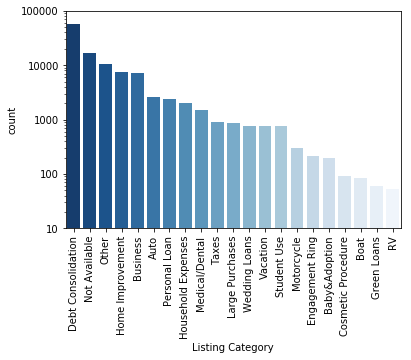

```python
#loan_order=['Cancelled', 'Chargedoff', 'Completed', 'Current', 'Defaulted', 'FinalPaymentInProgress', 'Past Due (1-15 days)',

base_color = sb.color_palette()[0]
ax=sb.countplot(data = loan_df, x = 'ListingCategory (numeric)', order=ListingCategory_order, palette='Blues_r')

plt.yscale('log')
tick_locs = [10, 100, 1000, 10000, 100000]
plt.yticks(tick_locs, tick_locs);

ax.set_xticklabels(ListingCategory_dict_order)
plt.xticks(rotation = 90)
plt.xlabel('Listing Category');
```

We can see that the most popular loan requests are for 'Debt Consolidation', and the least one for 'RV' (Recreational vehicle?)

### 1.7 Employment status

```python
loan_df['EmploymentStatus'].value_counts()
```

```
Employed         67322
Full-time        26355
Self-employed     6134
Not available     5347
Other             3806
Part-time         1088
Not employed       835
Retired            795
Name: EmploymentStatus, dtype: int64
```

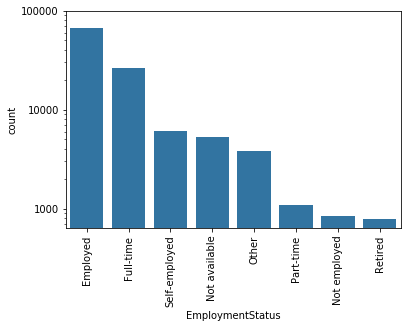

```python
sb.countplot(data = loan_df, x = 'EmploymentStatus', color=base_color, order=loan_df['EmploymentStatus'].value_counts().index)
plt.yscale('log')

tick_locs = [1000, 10000, 100000]
plt.yticks(tick_locs, tick_locs);

plt.xticks(rotation = 90);
```

Most requests are made by employed (incl. full-time and self-employed) individuals.

### 1.8 Is borrower Home owner

```python
loan_df['IsBorrowerHomeowner'].value_counts()
```

```
True     57478
False    56459
Name: IsBorrowerHomeowner, dtype: int64
```

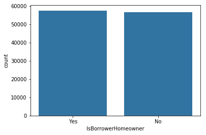

```python
ax=sb.countplot(data = loan_df, x = 'IsBorrowerHomeowner', color=base_color, order=[True, False])
ax.set_xticklabels(['Yes','No']);
```

Approximately 50/50 of individuals are homeowners or not. Can this influence decision on loan funding?

### 1.9 Credit Score Range Lower & Upper

```python
loan_df[['CreditScoreRangeLower', 'CreditScoreRangeUpper' ]].head()
```

|  | CreditScoreRangeLower | CreditScoreRangeUpper |
| --- | --- | --- |
| 0 | 640.0 | 659.0 |
| 1 | 680.0 | 699.0 |
| 2 | 480.0 | 499.0 |
| 3 | 800.0 | 819.0 |
| 4 | 680.0 | 699.0 |

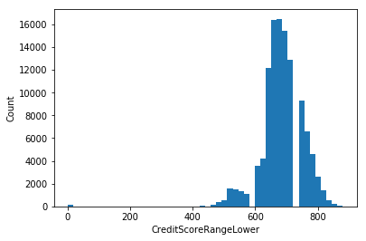

```python
plt.hist(loan_df['CreditScoreRangeLower'], bins=50);
plt.ylabel('Count')
plt.xlabel('CreditScoreRangeLower');
```

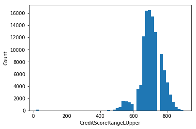

```python
plt.hist(loan_df['CreditScoreRangeUpper'], bins=50);
plt.ylabel('Count')
plt.xlabel('CreditScoreRangeLUpper');
```

Credit score looks normally distributed with slightly left skewedness. Interesting that distribution has gaps.

### 1.10 Inquiries Last 6 Months

```python
loan_df['InquiriesLast6Months'].dtype
```

```
dtype('float64')
```

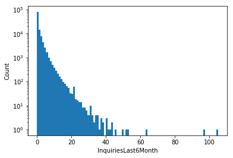

```python
plt.hist(loan_df['InquiriesLast6Months'], bins=100);
plt.yscale('log')
plt.ylabel('Count')
plt.xlabel('InquiriesLast6Month');
```

Most of the records have number of inquiries less than 10. Distribution is right skewed.

### 1.11 Debt to Income Ratio

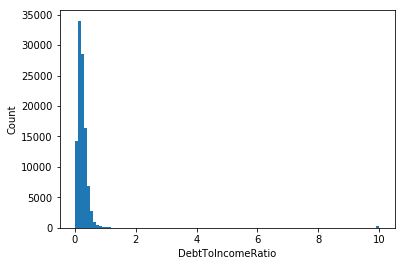

```python
plt.hist(loan_df['DebtToIncomeRatio'], bins=100);
#plt.yscale('log')
plt.ylabel('Count')
plt.xlabel('DebtToIncomeRatio');
```

We can see some outliers on the right around 10. Any debt to income ratio over 1000% is captured as 1001% (10.01)

```python
loan_df[loan_df['DebtToIncomeRatio']>5].shape[0]
```

```
333
```

```python
loan_df[loan_df['DebtToIncomeRatio']>5]['DebtToIncomeRatio'].head()
```

```
22       9.20
226     10.01
576     10.01
626     10.01
1242    10.01
Name: DebtToIncomeRatio, dtype: float64
```

Let's zoom on the interval [0, 1.5]

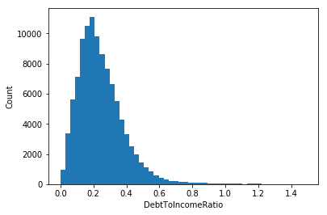

```python
plt.hist(loan_df[loan_df['DebtToIncomeRatio']<1.5]['DebtToIncomeRatio'], bins=50);
plt.ylabel('Count')
plt.xlabel('DebtToIncomeRatio');
```

```python
loan_df[loan_df['DebtToIncomeRatio']<1.5]['DebtToIncomeRatio'].describe()
```

```
count    104826.000000
mean          0.241856
std           0.142864
min           0.000000
25%           0.140000
50%           0.220000
75%           0.310000
max           1.490000
Name: DebtToIncomeRatio, dtype: float64
```

The distribution is right skewed, with median on 0.22 and mean around 0.24

### 1.12 Income Range

```python
loan_df['IncomeRange'].value_counts().sort_index().index
```

```
Index(['$0', '$1-24,999', '$100,000+', '$25,000-49,999', '$50,000-74,999',
       '$75,000-99,999', 'Not displayed', 'Not employed'],
      dtype='object')
```

```python
incomerange_order=['$0', '$1-24,999',  '$25,000-49,999', '$50,000-74,999',
       '$75,000-99,999', '$100,000+', 'Not displayed', 'Not employed']
```

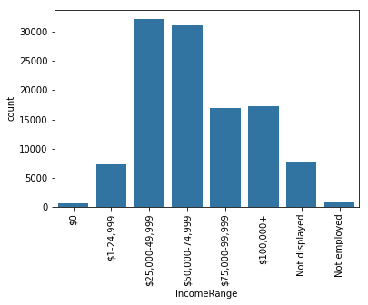

```python
sb.countplot(data = loan_df, x = 'IncomeRange', color=base_color,
                order=incomerange_order)
plt.xticks(rotation = 90);
```

We see that most inquiries have income range between 25 and 75 thousands.

### 1.13 Stated Monthly income

```python
loan_df['StatedMonthlyIncome'].describe()
```

```
count    1.139370e+05
mean     5.608026e+03
std      7.478497e+03
min      0.000000e+00
25%      3.200333e+03
50%      4.666667e+03
75%      6.825000e+03
max      1.750003e+06
Name: StatedMonthlyIncome, dtype: float64
```

We can see that the minimum monthly income is 0 USD and maximum is about 1.75 mln USD. Quite a big range, when mean and median is about few thousands USD.

```python
(loan_df['StatedMonthlyIncome']<100).sum()
```

```
1759
```

```python
loan_df[loan_df['StatedMonthlyIncome']<100]['IncomeRange'].value_counts()
```

```
Not employed      751
$0                621
$1-24,999         241
Not displayed     141
$100,000+           2
$25,000-49,999      2
$50,000-74,999      1
Name: IncomeRange, dtype: int64
```

Lots of records has monthly income less than 100 USD. If we compare values of the 'Stated Monthly income' and 'Income Range' columns we see that some people who indicated their yearly income to be higher than 25 thousands USD still inserted monthly salary less than 100 USD. We need to pay extra attention to how 'Stated Monthly income' is filled in, and maybe ignore incorrect values in case we want to use this variable in our analysis.

```python
loan_df[loan_df['StatedMonthlyIncome']<100]['IncomeVerifiable'].value_counts()
```

```
False    1599
True      160
Name: IncomeVerifiable, dtype: int64
```

```python
loan_df[(loan_df['StatedMonthlyIncome']<100)& (loan_df['IncomeVerifiable'])]['StatedMonthlyIncome'].head(10)
```

```
626      3.833333
1356    48.333333
4885     0.000000
5146     0.000000
5169     0.000000
5567     0.833333
5743    83.333333
5806     5.833333
5976     0.083333
7871     3.000000
Name: StatedMonthlyIncome, dtype: float64
```

Only 9% of income values that are less than 100 USD are verifiable, the rest is maybe filled in randomly? However, even verifiable monthly salary sometime states ridiculous values, such as 3.8333 or 5.8333.

```python
loan_df[loan_df['StatedMonthlyIncome']>100]['IncomeVerifiable'].value_counts()
```

```
True     105099
False      7069
Name: IncomeVerifiable, dtype: int64
```

```python
# if we want to plot in logarithmic scale we need to get rid of 0s
loan_df.loc[loan_df['StatedMonthlyIncome']==0, 'StatedMonthlyIncome']=0.001
```

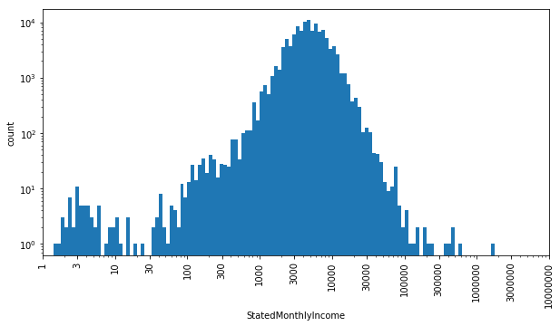

```python
plt.figure(figsize=[10, 5])
bin_edges = 10** np.arange(np.log10(loan_df['StatedMonthlyIncome'].min()), np.log10(loan_df['StatedMonthlyIncome'].max())+0.05, 0.05)
plt.hist(data = loan_df, x = 'StatedMonthlyIncome', bins=bin_edges)
plt.yscale('log')
#tick_locs = [1, 10, 100, 1000, 10000, 100000]
#plt.yticks(tick_locs, tick_locs);

plt.xscale('log')
tick_locs = [0.001,0.003, 0.01,0.03,1,3,10,30,100,300,1000,3000,10000,30000,100000,300000, 1000000,3000000, 10000000]
plt.xticks(tick_locs, tick_locs);
plt.xticks(rotation = 90);
plt.ylabel('count');
plt.xlabel('StatedMonthlyIncome');
plt.xlim(left=1) ;
#plt.xlim(1, 100)
```

The distribution looks to have few peaks, near 3 USD, 200 USD and 5000 USD. However, additional cleaning of monthly income is required to understand behaviour of monthly salaries less than 100, if it's just randomly filled in or not.

### 1.14 Total Prosper Loans

```python
# change N/A values to 0s
loan_df.loc[loan_df['TotalProsperLoans'].isna(), 'TotalProsperLoans']=0
```

```python
loan_df['TotalProsperLoans'].value_counts()
```

```
0.0    91853
1.0    15538
2.0     4540
3.0     1447
4.0      417
5.0      104
6.0       29
7.0        8
8.0        1
Name: TotalProsperLoans, dtype: int64
```

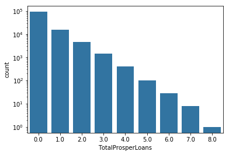

```python
sb.countplot(data = loan_df, x = 'TotalProsperLoans', color=base_color)
plt.yscale('log');
```

```python
print((loan_df[loan_df['TotalProsperLoans']>3]).shape[0]/loan_df['TotalProsperLoans'].shape[0]*100,
      (loan_df[loan_df['TotalProsperLoans']==0]).shape[0]/loan_df['TotalProsperLoans'].shape[0]*100)
```

```
0.49062201040926123 80.61735871578153
```

Approximately 0.5% has more than 3 loans, and 80% null loans and number of Prosper loans follows exponential distribution.

### 1.15 Loan original amount

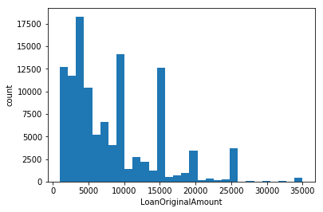

```python
plt.hist(data = loan_df, x = 'LoanOriginalAmount', bins=30);
#plt.yscale('log')
plt.ylabel('count');
plt.xlabel('LoanOriginalAmount');
```

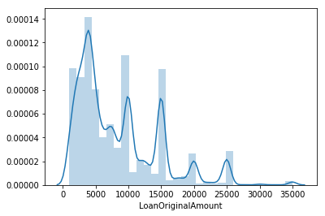

```python
sb.distplot(loan_df['LoanOriginalAmount'], bins = 30, hist_kws = {'alpha' : 0.3});
```

The distribution is strongly skewed right and have many high peaks in-between.

### 1.16 Loan Origination Date & Loan Origination Quarter

```python
# change format to date-time
loan_df['ListingCreationDate']=pd.to_datetime(loan_df['ListingCreationDate'])
loan_df['LoanOriginationDate']=pd.to_datetime(loan_df['LoanOriginationDate'])
```

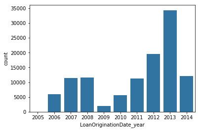

```python
loan_df['LoanOriginationDate_year']=pd.DatetimeIndex(loan_df['LoanOriginationDate']).year
sb.countplot(data = loan_df, x = 'LoanOriginationDate_year', color=base_color);
```

The distribution for Loan Origination Date looks bimodal with gap in 2009, due to 2008 financial crisis. Let's have closer look in data per quarters.

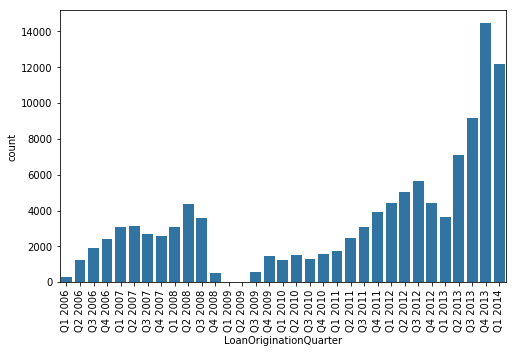

```python
quarters_order=['Q1 2006', 'Q2 2006', 'Q3 2006', 'Q4 2006',
              'Q1 2007', 'Q2 2007', 'Q3 2007', 'Q4 2007',
              'Q1 2008', 'Q2 2008', 'Q3 2008', 'Q4 2008',
              'Q1 2009', 'Q2 2009', 'Q3 2009', 'Q4 2009',
              'Q1 2010', 'Q2 2010', 'Q3 2010', 'Q4 2010',
              'Q1 2011', 'Q2 2011', 'Q3 2011', 'Q4 2011',
              'Q1 2012', 'Q2 2012', 'Q3 2012', 'Q4 2012',
              'Q1 2013', 'Q2 2013', 'Q3 2013', 'Q4 2013',
              'Q1 2014']
plt.figure(figsize=[8, 5])
sb.countplot(loan_df['LoanOriginationQuarter'], color=base_color, order=quarters_order)
plt.xticks(rotation = 90);
#plt.yscale('log')
```

```python
(loan_df['LoanOriginationQuarter']=='Q1 2009').sum()+(loan_df['LoanOriginationQuarter']=='Q2 2009').sum()
```

```
13
```

We can see that in Q1 and Q2 of 2009 almost none (only 13) loans were originated. The peaks of originated loans were in Q1/2 2007, Q2 2008, Q3 2012 and Q4 2013

### 1.17 Monthly loan Payment

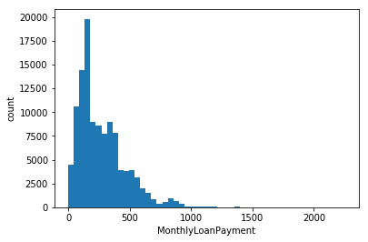

```python
plt.hist(data = loan_df, x = 'MonthlyLoanPayment', bins=50);
#plt.yscale('log')
plt.ylabel('count');
plt.xlabel('MonthlyLoanPayment');
```

```python
loan_df['MonthlyLoanPayment'].describe()
```

```
count    113937.000000
mean        272.475783
std         192.697812
min           0.000000
25%         131.620000
50%         217.740000
75%         371.580000
max        2251.510000
Name: MonthlyLoanPayment, dtype: float64
```

The distribution of monthly loan payments is right skewed.

### 1.18 Recommendations

```python
loan_df['Recommendations'].value_counts()
```

```
0     109678
1       3516
2        568
3        108
4         26
5         14
9          6
7          5
6          4
8          3
16         2
18         2
24         1
14         1
19         1
21         1
39         1
Name: Recommendations, dtype: int64
```

```python
loan_df[loan_df['Recommendations']==0].shape[0]/loan_df['Recommendations'].shape[0]*100
```

```
96.26196933393015
```

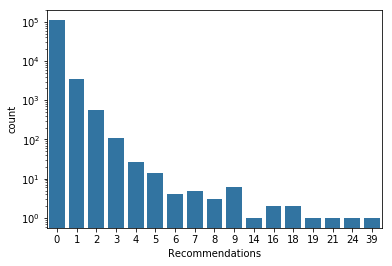

```python
sb.countplot(data = loan_df, x = 'Recommendations', color=base_color);
plt.yscale('log');
```

96% of inquiries has null recommendations and only few have more than 10.

### 1.19 Investment from Friends

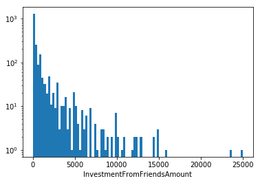

```python
# plot distribution of friends investments without 0 investments
plt.hist(loan_df[loan_df['InvestmentFromFriendsAmount']>0]['InvestmentFromFriendsAmount'], bins=100)
plt.yscale('log');
plt.xlabel('InvestmentFromFriendsAmount');
```

```python
loan_df[loan_df['InvestmentFromFriendsAmount']>15000]['InvestmentFromFriendsAmount']
```

```
14716     23699.52
58008     25000.00
113704    16000.00
Name: InvestmentFromFriendsAmount, dtype: float64
```

```python
loan_df[loan_df['InvestmentFromFriendsAmount']>0]['InvestmentFromFriendsAmount'].describe()
```

```
count     2131.000000
mean       884.909850
std       1967.726005
min         25.000000
25%         65.000000
50%        190.000000
75%        750.000000
max      25000.000000
Name: InvestmentFromFriendsAmount, dtype: float64
```

We see that average friends investments is less than 1 thousands USD, but two of records has friends investment of 23,699 and 25,000 USD

### 1.19a Ratio of Investment from Friends and Loan Original Amount

```python
loan_df['Ratio_FriendsInv_LoanAmount']=loan_df['InvestmentFromFriendsAmount']/loan_df['LoanOriginalAmount']
```

```python
loan_df[loan_df['Ratio_FriendsInv_LoanAmount']>0.99][['Ratio_FriendsInv_LoanAmount', 'LoanOriginalAmount', 'InvestmentFromFriendsAmount']].head(10)
```

|  | Ratio_FriendsInv_LoanAmount | LoanOriginalAmount | InvestmentFromFriendsAmount |
| --- | --- | --- | --- |
| 605 | 1.016664 | 6001 | 6101.0 |
| 790 | 1.000000 | 1000 | 1000.0 |
| 2881 | 1.000000 | 1000 | 1000.0 |
| 3455 | 1.000000 | 3000 | 3000.0 |
| 4254 | 1.000000 | 1000 | 1000.0 |
| 5241 | 1.000000 | 5500 | 5500.0 |
| 5380 | 1.000000 | 4500 | 4500.0 |
| 6286 | 1.000000 | 2750 | 2750.0 |
| 8304 | 1.000000 | 10000 | 10000.0 |
| 8645 | 1.000000 | 5000 | 5000.0 |

```python
loan_df[loan_df['InvestmentFromFriendsAmount']>15000][['Ratio_FriendsInv_LoanAmount', 'LoanOriginalAmount', 'InvestmentFromFriendsAmount', 'Investors']]
```

|  | Ratio_FriendsInv_LoanAmount | LoanOriginalAmount | InvestmentFromFriendsAmount | Investors |
| --- | --- | --- | --- | --- |
| 14716 | 0.947981 | 25000 | 23699.52 | 90 |
| 58008 | 1.000000 | 25000 | 25000.00 | 2 |
| 113704 | 1.000000 | 16000 | 16000.00 | 1 |

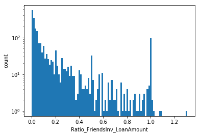

```python
# plot distribution of friends investments without 0 investments
plt.hist(loan_df[loan_df['Ratio_FriendsInv_LoanAmount']>0]['Ratio_FriendsInv_LoanAmount'], bins=100)
plt.yscale('log');
plt.ylabel('count');
plt.xlabel('Ratio_FriendsInv_LoanAmount');
```

Does the investment from friends actually fund the requested Loan Original Amount or is it in addition to the Loan Original Amount? If yes, then if ratio > 1, the loan was completely funded by friends.

### 1.20 Investors

```python
# loan_df['Investors'].value_counts()
```

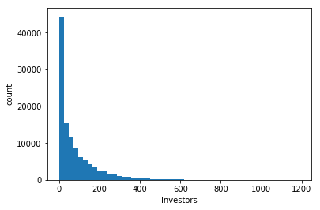

```python
plt.hist(data = loan_df, x = 'Investors', bins=50);
#plt.yscale('log')
plt.ylabel('count');
plt.xlabel('Investors');
```

```python
print (loan_df[loan_df['Investors']==1].shape[0]/loan_df.shape[0]*100)
print (loan_df[loan_df['Investors']==2].shape[0]/loan_df.shape[0]*100)
print (loan_df[loan_df['Investors']==3].shape[0]/loan_df.shape[0]*100)
```

```
24.411736310417158
1.216461728850154
0.8697789129080105
```

24% of inquiries are funded by only one investor.

### Discuss the distribution(s) of your variable(s) of interest. Were there any unusual points? Did you need to perform any transformations?

By examining single variables we saw that Borrower Rate/APR is normally distributed with mean at about 18-20%. The user score range looks a bit skewed left, with few strange gaps. Furthermore, we observed quite a big percentage of non-performing (charged off, defaulted, Past-Due) loans in the data. As an investor you should be conscious about performance of your money and the system that provide such high amount of bad loans needs improvement.

I made new variable that describe performance of the loans. It contains the following list of values: 'Non-Performing', 'Performing' and 'Current'. Furthermore, I combined two different Rating column for records before and after in one.

### Of the features you investigated, were there any unusual distributions? Did you perform any operations on the data to tidy, adjust, or change the form of the data? If so, why did you do this?

Most of cleaning was related to perform correct ordering for displaying and in some cases scaling of axis were required.

The strange variable in monthly income, with in some cases do not correspond to indicated yearly salary. Therefore, this needs extra attention, but we will not use this variable any further in our analysis.

## 2 Bivariate Exploration

### 2.1 Time vs Loan Duration

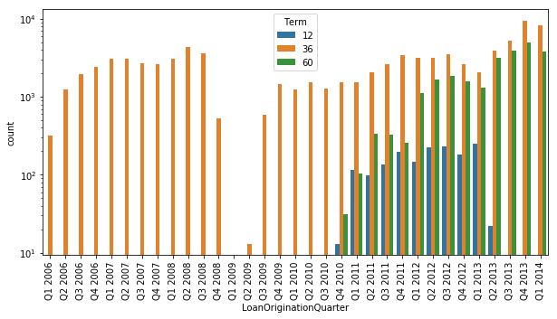

```python
plt.figure(figsize=[10, 5])
sb.countplot(data = loan_df, x = 'LoanOriginationQuarter', hue = 'Term',  order=quarters_order, palette='tab10');
plt.xticks(rotation=90);
plt.yscale('log');
```

Actually, we see that loans with duration of 1 and 5 years was introduced only in Q4 2010. For the 5 years loan duration we can see increasing behaviour.

Amount of loans with duration of 3 years increased in 2013.

Gap in Q1 & 2 of 2009 is due to financial crisis.

### 2.2 Time vs Loan Original Amount

```python
#loan_df.groupby('LoanOriginationQuarter').mean()['LoanOriginalAmount']
```

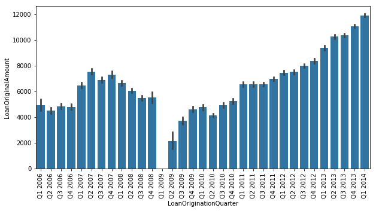

```python
plt.figure(figsize=[10, 5])
sb.barplot(data = loan_df, x = 'LoanOriginationQuarter', y = 'LoanOriginalAmount',  order=quarters_order, color=base_color);
plt.xticks(rotation=90);
#plt.yscale('log')
```

We can see that Loan average amount has increased over years, especially after the dip of 2008 it rise faster. Maybe by coincidence but before the end of 2008 there were decrease in average loan amount.

### 2.3 Time vs Borrower Rate

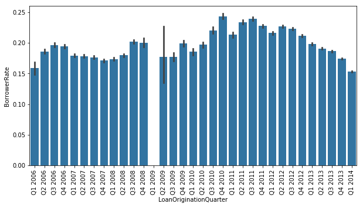

```python
plt.figure(figsize=[10, 5])
sb.barplot(data = loan_df, x = 'LoanOriginationQuarter', y = 'BorrowerRate',  order=quarters_order, color=base_color);
plt.xticks(rotation=90);
#plt.yscale('log')
```

### 2.4 Time vs Loan Performance

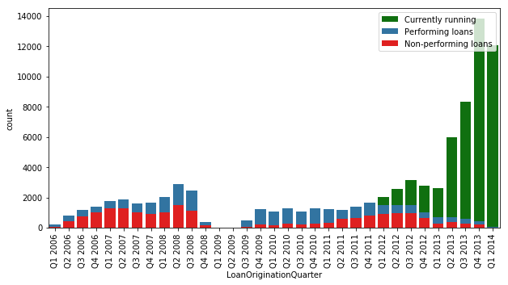

```python
plt.figure(figsize=[10, 5])
ax=sb.countplot(data=loan_df[loan_df['Performing']=='Current'], x = 'LoanOriginationQuarter', color='green', order=quarters_order)
sb.countplot(data=loan_df[loan_df['Performing']=='Performing'], x = 'LoanOriginationQuarter', color=base_color, order=quarters_order)
sb.countplot(data=loan_df[loan_df['Performing']=='Non-Performing'], x = 'LoanOriginationQuarter', color='red', order=quarters_order)
plt.xticks(rotation=90);
ax.legend(['Currently running','Performing loans', 'Non-performing loans']);
```

Amount of non-performing loans in 2006-2008 was higher than after 2009.

Here I plotted distribution one over other.

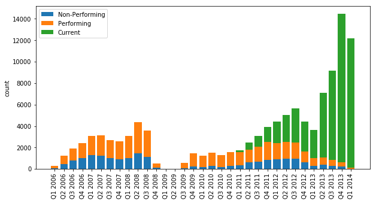

```python
# code from udacity lessons
cat1_order=quarters_order
cat2_order=['Non-Performing', 'Performing', 'Current']
plt.figure(figsize=[10, 5])
baselines = np.zeros(len(cat1_order))
# for each second-variable category:
for i in range(len(cat2_order)):
    # isolate the counts of the first category,
    cat2 = cat2_order[i]
    inner_counts = loan_df[loan_df['Performing'] == cat2]['LoanOriginationQuarter'].value_counts()
    # then plot those counts on top of the accumulated baseline
    plt.bar(x = np.arange(len(cat1_order)), height = inner_counts[cat1_order],
            bottom = baselines)
    baselines += inner_counts[cat1_order]


plt.xticks(np.arange(len(cat1_order)), cat1_order)
plt.legend(cat2_order, loc = 2)
plt.xticks(rotation=90);
plt.ylabel('count');
```

Here bars are stacked on top of each other.

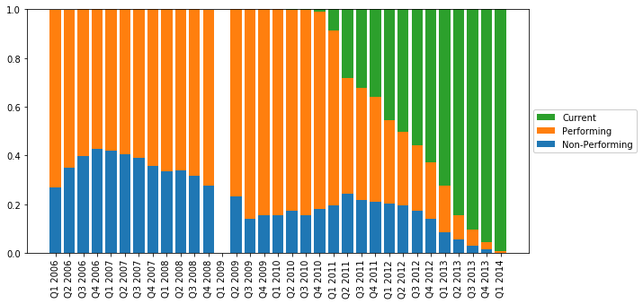

```python
plt.figure(figsize=[10, 5])
sort_ref = [] # for storing references to plot elements
baselines = np.zeros(len(cat1_order))
cat1_counts = loan_df['LoanOriginationQuarter'].value_counts()

# for each second-variable category:
for i in range(len(cat2_order)):
    # isolate the counts of the first category,
    cat2 = cat2_order[i]
    inner_counts = loan_df[loan_df['Performing'] == cat2]['LoanOriginationQuarter'].value_counts()
    inner_props = inner_counts / cat1_counts
    # then plot those counts on top of the accumulated baseline
    bars = plt.bar(x = np.arange(len(cat1_order)),
                   height = inner_props[cat1_order],
                   bottom = baselines)
    sort_ref.append(bars)
    baselines += inner_props[cat1_order]

plt.xticks(np.arange(len(cat1_order)), cat1_order)
plt.legend(reversed(sort_ref), reversed(cat2_order), framealpha = 1,
           bbox_to_anchor = (1, 0.5), loc = 6);
plt.xticks(rotation=90);
```

Now staked bars are normalised to one over each time interval.

It's interesting to see how non-performing rate behaved over the years.

```python
Perfomance_df = loan_df.groupby(['LoanOriginationQuarter', 'Performing']).size().reset_index().pivot(columns='Performing',index='LoanOriginationQuarter', values=0)
Perfomance_df.reset_index(level=0, inplace=True)
Perfomance_df['NonPerformingPercent']=Perfomance_df['Non-Performing']/(Perfomance_df['Non-Performing']+Perfomance_df['Performing'])*100
#df_plot.plot(x=df_plot.index, kind='bar', stacked=True)
#Perfomance_df
```

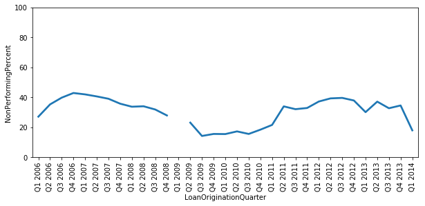

```python
plt.figure(figsize = [10,4])

ax = sb.pointplot(data = Perfomance_df, x = 'LoanOriginationQuarter', y = 'NonPerformingPercent',
                  markers="",order=quarters_order,  join=True,                ci=None)
plt.xticks(rotation = 90)
plt.ylim(0, 100);
```

Loans for period between 2011 and 2014 is not yet fully completed, since some of the loans are still running (3- and 5-years loans). However, we can assume that 3-year loans from 2011 & 2012 are almost at their completion and will be positively completed, or have been already defaulted. Thus, we can assume that Non Performance percentage in 2011 and 2012 will be only reduced.

In the period before 2009 the non-performance percentage reached it maximum in Q4 2006 (42.9%) and was following reduction pattern before 2008 crisis.

From 2009 the non-performance percentage gradually increased.

Prosper should pay extra attention to the ration of positively performing and non-performing loans.

### 2.5 Home Owner Vs Loan Status

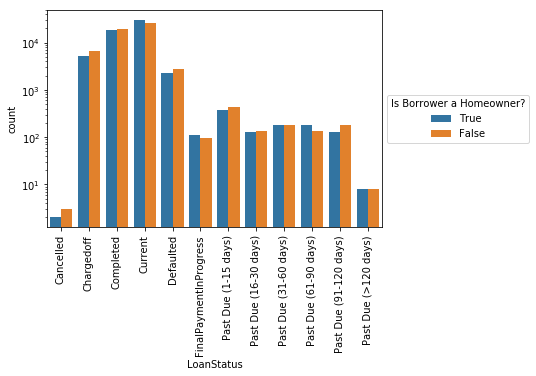

```python
ax=sb.countplot(data = loan_df, x = 'LoanStatus', hue = 'IsBorrowerHomeowner', order=loan_order, hue_order=[True, False]);
plt.xticks(rotation=90);
ax.legend(loc = 6,  bbox_to_anchor = (1.0, 0.5), title="Is Borrower a Homeowner?")
plt.yscale('log');
```

In general, it seems that house owner status doesn't influence the loan performance.

### 2.6 Home Owner vs Loan Original Amount

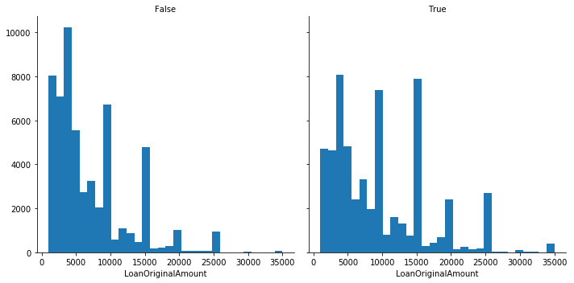

```python
#bin_edges = 10** np.arange(np.log10(diamonds['price'].min()), np.log10(diamonds['price'].max())+0.1, 0.05)
g=sb.FacetGrid(data = loan_df, col = 'IsBorrowerHomeowner', col_wrap = 2, height = 5)
                     #col_order = color_order)
g.map(plt.hist, 'LoanOriginalAmount', bins = 30)
g.set_titles('{col_name}');
#plt.xscale('log')
```

```python
loan_df.groupby('IsBorrowerHomeowner').describe()['LoanOriginalAmount']
```

| IsBorrowerHomeowner | count | mean | std | min | 25% | 50% | 75% | max |
| --- | --- | --- | --- | --- | --- | --- | --- | --- |
| False | 56459.0 | 7033.868294 | 5358.737876 | 1000.0 | 3000.0 | 5000.0 | 10000.0 | 35000.0 |
| True | 57478.0 | 9617.056561 | 6768.715407 | 1000.0 | 4000.0 | 8000.0 | 15000.0 | 35000.0 |

We can see that 'Loan original amount' histogram by non-homeowners is narrower and higher than the one for home owners. The homeowners borrow larger amounts.

### 2.7 Income Range vs Loan Original Amount

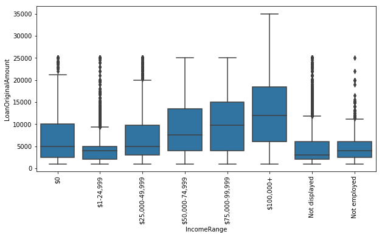

```python
plt.figure(figsize=[10, 5])
sb.boxplot(data = loan_df, x = 'IncomeRange', y = 'LoanOriginalAmount',  color=base_color, order=incomerange_order);
plt.xticks(rotation=90);
```

We can observe tendency that people with higher income ask for higher loans. Interesting that people with 0 USD as income ask a bit higher loans than people from group '1-24,999 USD'. Probably some people indicated their income range incorrectly.

### 2.8 Prosper Rating Vs Borrower Rate

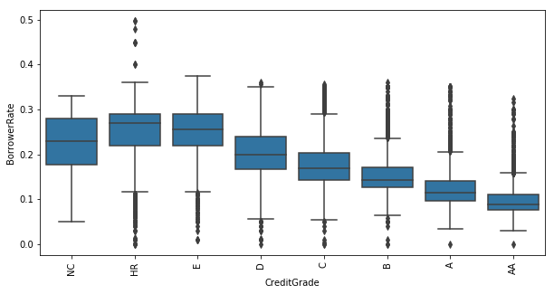

```python
# before 2009
plt.figure(figsize=[10, 5])
sb.boxplot(data = loan_df, x = 'CreditGrade', y = 'BorrowerRate',  color=base_color, order=CreditGrade_order);
plt.xticks(rotation=90);
```

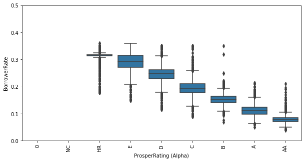

```python
# after 2009
plt.figure(figsize=[10, 5])
ax=sb.boxplot(data = loan_df, x = 'ProsperRating (Alpha)', y = 'BorrowerRate',  color=base_color, order=ProsperRating_order);
plt.xticks(rotation=90);
ax.set_ylim(0,0.5);
```

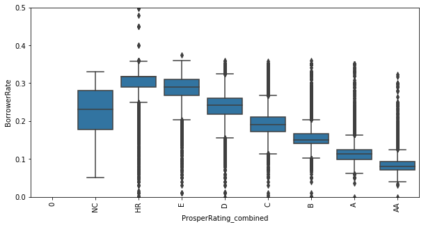

```python
plt.figure(figsize=[10, 5])
ax=sb.boxplot(data = loan_df, x = 'ProsperRating_combined', y = 'BorrowerRate',  color=base_color, order=ProsperRating_order);
plt.xticks(rotation=90);
ax.set_ylim(0,0.5);
```

Borrowers with higher risk get higher rates.

### 2.9 Income range Vs Prosper Rating

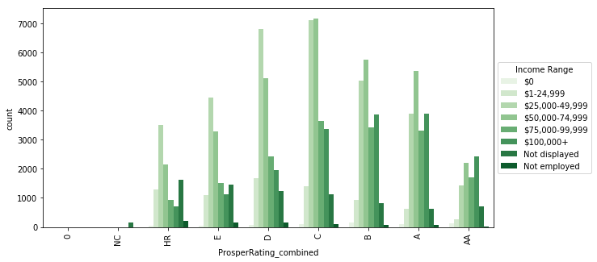

```python
plt.figure(figsize=[10, 5])

ax=sb.countplot(data = loan_df, x = 'ProsperRating_combined', hue = 'IncomeRange', order=ProsperRating_order,
                hue_order=incomerange_order, palette='Greens');
plt.xticks(rotation=90);
ax.legend(loc = 6,  bbox_to_anchor = (1.0, 0.5), title="Income Range");
#plt.yscale('log')
```

We see that people with income in range 1-25,000 has right skewed distribution with peak as 'D' - rating, while people with income over 100,000 left skewed distribution with peak rate of 'A'. Let's plot this distributions per each income range separately.

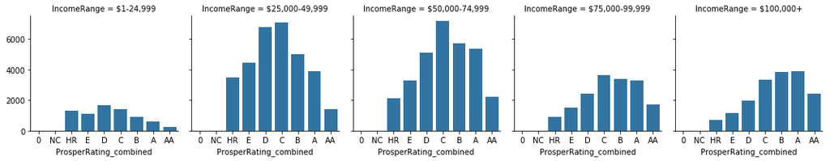

```python
g=sb.FacetGrid(data = loan_df[(loan_df['IncomeRange']=='$1-24,999')|(loan_df['IncomeRange']=='$25,000-49,999')|
                              (loan_df['IncomeRange']=='$50,000-74,999')|
                              (loan_df['IncomeRange']=='$75,000-99,999')|
                              (loan_df['IncomeRange']=='$100,000+')], col = 'IncomeRange', col_wrap = 5, height = 3,
                     col_order = ['$1-24,999',  '$25,000-49,999', '$50,000-74,999',
       '$75,000-99,999', '$100,000+'])
g.map(sb.countplot, 'ProsperRating_combined', order=ProsperRating_order);
```

### 2.10 Credit Score Range Upper/Lower vs Borrower Rate/APR

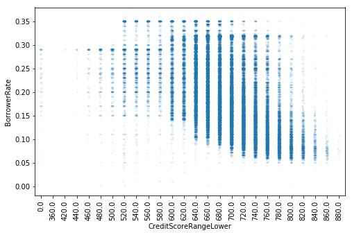

```python
plt.figure(figsize=[8, 5])
sb.stripplot(data = loan_df, x = 'CreditScoreRangeLower', y = 'BorrowerRate', alpha=0.05, marker='.', jitter=True, color=base_color)
plt.xticks(rotation=90);
```

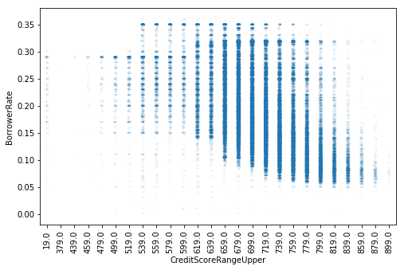

```python
plt.figure(figsize=[8, 5])
sb.stripplot(data = loan_df, x = 'CreditScoreRangeUpper', y = 'BorrowerRate', alpha=0.05, marker='.', jitter=True, color=base_color)
plt.xticks(rotation=90);
```

```python
loan_df['CreditScoreRangeUpper'].corr(loan_df['BorrowerRate'])
```

```
-0.46156667742854984
```

Some negative dependency between Credit Score Range and Borrower Rate is present here.

### 2.11 Borrower Rate/APR vs Loan Original Amount

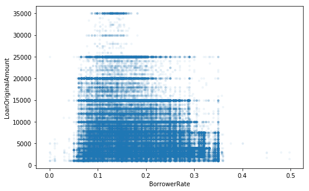

```python
plt.figure(figsize=[8, 5])
plt.scatter(data = loan_df, x = 'BorrowerRate', y = 'LoanOriginalAmount', alpha=0.05, marker='.', color=base_color)
#sb.stripplot(data = loan_df, x = 'BorrowerRate', y = 'LoanOriginalAmount', alpha=0.05, marker='.', jitter=True, color=base_color)
#plt.xticks(rotation=90);
plt.xlabel('BorrowerRate')
plt.ylabel('LoanOriginalAmount');
```

```python
loan_df['LoanOriginalAmount'].corr(loan_df['BorrowerRate'])
```

```
-0.3289599499385361
```

No strong correlation is observed here.

### 2.12 Credit Score Rande Upper/Lower vs Loan Original Amount

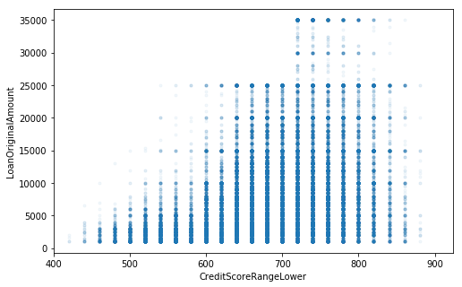

```python
plt.figure(figsize=[8, 5])
plt.scatter(data = loan_df, x = 'CreditScoreRangeLower', y = 'LoanOriginalAmount', alpha=0.05, marker='.', color=base_color)
plt.xlim(left=400)
plt.xlabel('CreditScoreRangeLower')
plt.ylabel('LoanOriginalAmount');
```

```python
loan_df['LoanOriginalAmount'].corr(loan_df['CreditScoreRangeLower'])
```

```
0.34087445147842615
```

No strong correlation is visible here

### 2.13 Listing Category vs Loan Original Amount

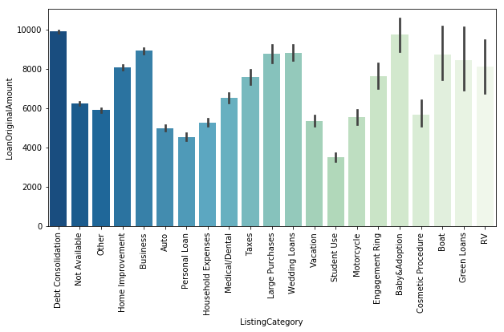

```python
#ax=sb.countplot(data = loan_df, x = 'ListingCategory (numeric)', order=ListingCategory_order)
plt.figure(figsize=[10, 5])
ax=sb.barplot(data = loan_df, x = 'ListingCategory (numeric)', y = 'LoanOriginalAmount',  order=ListingCategory_order, palette='GnBu_r');
plt.xticks(rotation=90);

ax.set_xticklabels(ListingCategory_dict_order)
plt.xticks(rotation = 90)
plt.xlabel('ListingCategory');
```

```python
#ListingCategory_dict_order
```

```python
#loan_df.groupby('ListingCategory (numeric)').mean()['LoanOriginalAmount']
```

```python
print (ListingCategory_dict[1],ListingCategory_dict[8], ListingCategory_dict[5])
```

```
Debt Consolidation Baby&Adoption Student Use
```

For 'Debt Consolidation' and 'Baby&Adoption' people ask in average the highest average loan amount, while the lowest average loan amount is asked for 'Student Use'.

### 2.14 Loan Original Amount vs Monthly Loan Payment

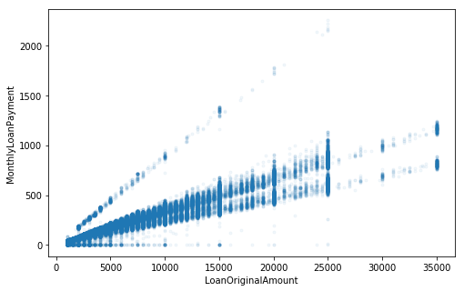

```python
plt.figure(figsize=[8, 5])
plt.scatter(data = loan_df, y = 'MonthlyLoanPayment', x = 'LoanOriginalAmount', alpha=0.05, marker='.', color=base_color)
#sb.stripplot(data = loan_df, x = 'BorrowerRate', y = 'LoanOriginalAmount', alpha=0.05, marker='.', jitter=True, color=base_color)
#plt.xticks(rotation=90);
plt.ylabel('MonthlyLoanPayment')
plt.xlabel('LoanOriginalAmount');
```

```python
loan_df['LoanOriginalAmount'].corr(loan_df['MonthlyLoanPayment'])
```

```
0.9319836797293988
```

We can see positive dependency between Loan Amount and Monthly Loan Payment, which is quite logical.

### Talk about some of the relationships you observed in this part of the investigation. How did the feature(s) of interest vary with other features in the dataset?

The highest average Prosper Borrower Rate had its maximum in q4 2010, after that it decreased.

Bad performing rate is quite high over the years and didn't improve a lot after 2008 financial crisis.

Borrower Rate is strongly dependent on Prosper Rate and has different behaviour for users with different income.

### Did you observe any interesting relationships between the other features (not the main feature(s) of interest)?

The analysis showes that 1- and 5- year term were introduced only at the end of the 2010, and while 5-year loan duration became more popular over time, the 1- year slowly disappeared.

It's also interesting to see that loan amount increased over time and highest average loans are made for loan consolidation.

Moreover, we saw strong dependency between loan amount and monthly payment.

## 3 Multivariate Exploration

### 3.1 Borrow Rate vs LoanOriginalAmount vs Performing

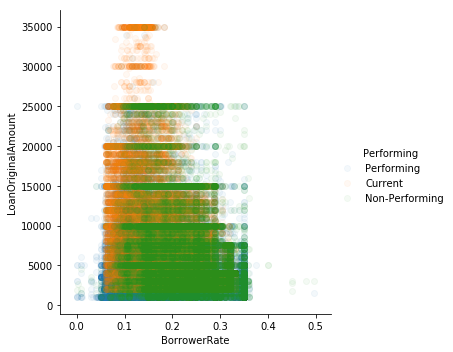

```python
g = sb.FacetGrid(data = loan_df, hue = 'Performing', height = 5)
g.map(plt.scatter, 'BorrowerRate', 'LoanOriginalAmount',alpha=0.05)
g.add_legend();
#plt.xscale('log')
#x_ticks = [0.1, 0.3, 1, 3, 10, 30, 100, 300, 1000]
#plt.xticks(x_ticks, x_ticks);
```

We can't see any clear pattern between Borrower Rate and Loan Amount and its performance.

### 3.2 Borrower Rate vs Loan Amount vs Income Range

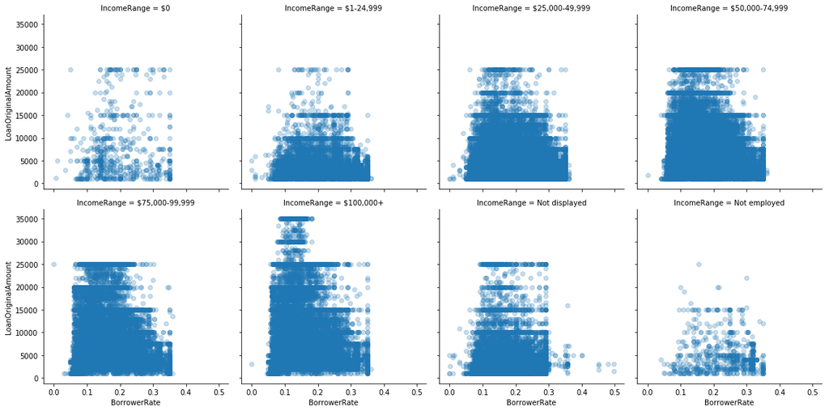

```python
g = sb.FacetGrid(data = loan_df, col = 'IncomeRange',  height = 4, col_wrap = 4,
                margin_titles = True, col_order=incomerange_order)
g.map(plt.scatter, 'BorrowerRate', 'LoanOriginalAmount', alpha=0.25)
plt.figure(figsize = [8,5]);
```

Borrower Rate vs Loan Amount presented for different income groups doesn't give too much insights.

### 3.3 Listing Category vs Loan Amount vs Performance

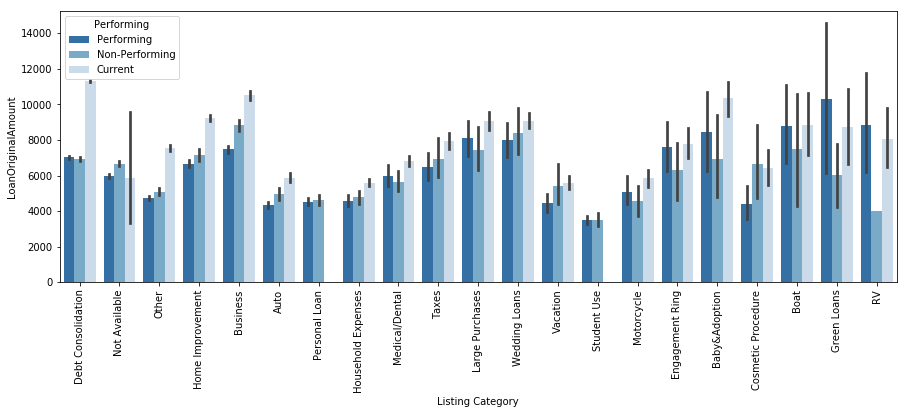

```python
#ax=sb.countplot(data = loan_df, x = 'ListingCategory (numeric)', order=ListingCategory_order)
plt.figure(figsize=[15, 5])
ax=sb.barplot(data = loan_df, x = 'ListingCategory (numeric)', y = 'LoanOriginalAmount', hue='Performing',  order=ListingCategory_order,
              hue_order=['Performing','Non-Performing', 'Current'],  palette='Blues_r');
plt.xticks(rotation=90);

ax.set_xticklabels(ListingCategory_dict_order)
plt.xticks(rotation = 90)
plt.xlabel('Listing Category');
```

Bad performing loans have slightly higher loan original amounts for some categories, but not rsignificant.

### 3.4 Prosper Rating vs Borrower Rate vs Performance

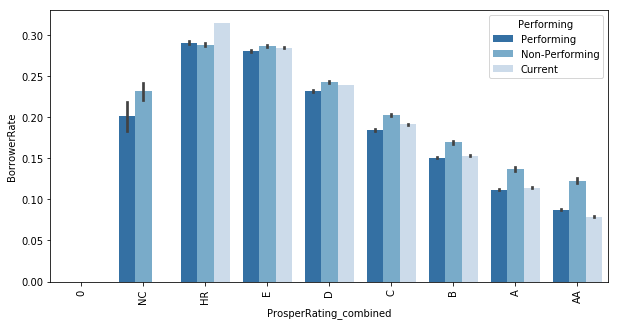

```python
#ax=sb.countplot(data = loan_df, x = 'ListingCategory (numeric)', order=ListingCategory_order)
plt.figure(figsize=[10, 5])
ax=sb.barplot(data = loan_df, x = 'ProsperRating_combined', y = 'BorrowerRate', hue='Performing',
              order=ProsperRating_order, palette='Blues_r',hue_order=['Performing','Non-Performing', 'Current']);
#plt.xticks(rotation=90);

#ax.set_xticklabels()
plt.xticks(rotation = 90)
plt.xlabel('ProsperRating_combined');
```

High (good) rated users with high borrower rate perform worse than users with lower Borrowed Rate.

### 3.5 Prosper Rating vs Borrower Rate vs before/after crisis

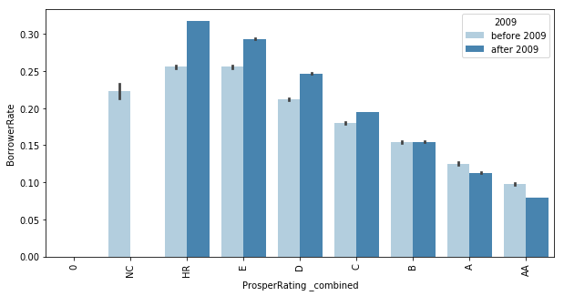

```python
#ax=sb.countplot(data = loan_df, x = 'ListingCategory (numeric)', order=ListingCategory_order)
plt.figure(figsize=[10, 5])
ax=sb.barplot(data = loan_df, x = 'ProsperRating_combined', y = 'BorrowerRate', hue='2009',  order=ProsperRating_order, palette='Blues');
#plt.xticks(rotation=90);

#ax.set_xticklabels()
plt.xticks(rotation = 90)
plt.xlabel('ProsperRating _combined');
```

Before 2009 high risk users received loans with lower rates.

### 3.6 Prosper Rating vs Loan Amount vs before/after crisis

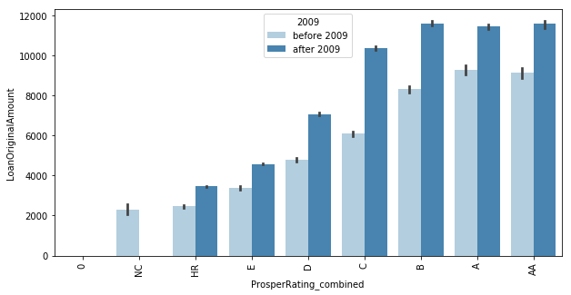

```python
#ax=sb.countplot(data = loan_df, x = 'ListingCategory (numeric)', order=ListingCategory_order)
plt.figure(figsize=[10, 5])
ax=sb.barplot(data = loan_df, x = 'ProsperRating_combined', y = 'LoanOriginalAmount', hue='2009',  order=ProsperRating_order,
             palette='Blues');
#plt.xticks(rotation=90);

#ax.set_xticklabels()
plt.xticks(rotation = 90)
plt.xlabel('ProsperRating_combined');
```

Loan amounts before 2009 was lower.

### 3.7 Prosper Rating vs Loan Amount vs Performance

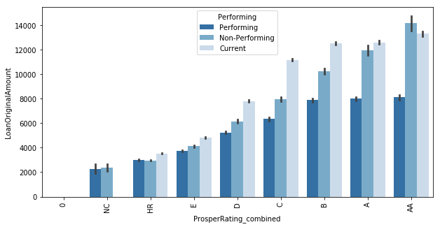

```python
#ax=sb.countplot(data = loan_df, x = 'ListingCategory (numeric)', order=ListingCategory_order)
plt.figure(figsize=[10, 5])
ax=sb.barplot(data = loan_df, x = 'ProsperRating_combined', y = 'LoanOriginalAmount', hue='Performing',
              order=ProsperRating_order, palette='Blues_r', hue_order=['Performing','Non-Performing', 'Current']);
#plt.xticks(rotation=90);

#ax.set_xticklabels()
plt.xticks(rotation = 90)
plt.xlabel('ProsperRating_combined');
```

The higher loan amount under good rated users the chance is bigger that this loan will not perform.

### 3.8 Time vs Loan Amount vs Performance

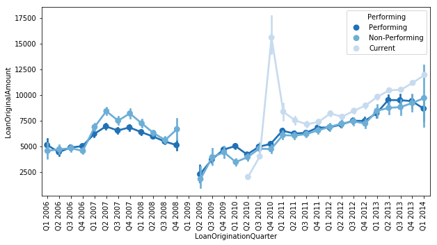

```python
plt.figure(figsize = [10,5])

ax = sb.pointplot(data = loan_df, x = 'LoanOriginationQuarter', y = 'LoanOriginalAmount', hue = 'Performing',
                  order=quarters_order, palette='Blues_r', dodge=True,  join=True,
                  hue_order=['Performing','Non-Performing', 'Current'])
plt.xticks(rotation = 90);
#ax.legend(['Non-performing loans', 'Performing loans', 'Currently running'])
```

In 2007-2008 higher loans performed worse than lower loans.

### 3.9 Time vs Loan Amount vs Income Range

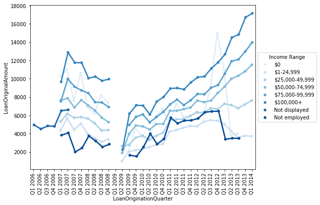

```python
plt.figure(figsize = [8,6])

ax = sb.pointplot(data = loan_df, x = 'LoanOriginationQuarter', y = 'LoanOriginalAmount', hue = 'IncomeRange',
                  markers=".",order=quarters_order,hue_order=incomerange_order, palette='Blues', dodge=True,  join=True,
                  ci=None)
plt.xticks(rotation = 90)
ax.legend(loc = 6,  bbox_to_anchor = (1.0, 0.5), title="Income Range");
#ax.legend(['Non-performing loans', 'Performing loans', 'Currently running'])
```

### 3.10 Time vs Borrower Rate vs Loan Duration

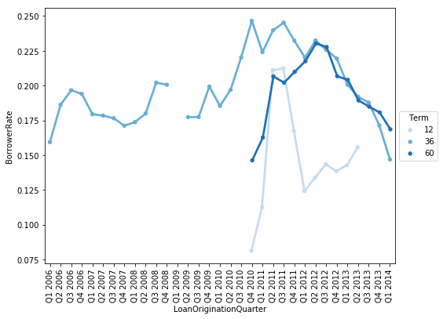

```python
plt.figure(figsize = [8,6])

ax = sb.pointplot(data = loan_df, x = 'LoanOriginationQuarter', y = 'BorrowerRate', hue = 'Term',
                  markers=".",order=quarters_order,hue_order=[12,36,60], palette='Blues', dodge=True,  join=True,
                  ci=None)
plt.xticks(rotation = 90)
ax.legend(loc = 6,  bbox_to_anchor = (1.0, 0.5), title="Term");
#ax.legend(['Non-performing loans', 'Performing loans', 'Currently running'])
```

Average Borrower rate for 1 year duration was lower than for 3 and 5 years. While at the beginning (in 2011) Borrower rate for 1 and 5 years were more attractive, after 2012 5 year Borrower Rate became unattractive (the same as for 3 years) and 1 year option completely disappeared.

### 3.11 Time vs Loan Amount vs Loan Duration

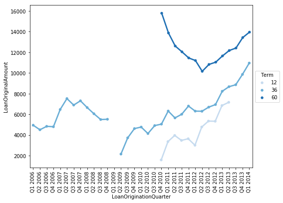

```python
plt.figure(figsize = [8,6])

ax = sb.pointplot(data = loan_df, x = 'LoanOriginationQuarter', y = 'LoanOriginalAmount', hue = 'Term',
                  markers=".",order=quarters_order,hue_order=[12,36,60], palette='Blues', dodge=True,  join=True,
                  ci=None)
plt.xticks(rotation = 90)
ax.legend(loc = 6,  bbox_to_anchor = (1.0, 0.5), title="Term");
#ax.legend(['Non-performing loans', 'Performing loans', 'Currently running'])
```

For higher loan amounts people are using loans with longer duration and for small sums short term loans are taken.